# Practical Machine Learning Course Project

Anthony Oliver A. Nagallo

August 10, 2019

### Introduction

In this project we will make a prediction model. The data used in thise project are provided by “Ugulino, W.; Cardador, D.; Vega, K.; Velloso, E.; Milidiu, R.; Fuks, H. Wearable Computing: Accelerometers’ Data Classification of Body Postures and Movements”

With use of devices such as Jawbone Up, Nike FuelBand, and Fitbit it has been easy to collect data about personal activity. These type of devices are part of the quantified self movement - a group of enthusiasts who take measurements about themselves regularly to improve their health, to find patterns in their behavior. One thing that people regularly do is quantify how much of a particular activity they do, but they rarely quantify how well they do it.

In this project, The goal will be to use data from accelerometers on the belt, forearm, arm, and dumbell of 6 participants. They were asked to perform barbell lifts correctly and incorrectly in 5 different ways.

### Methodology

In creating these project the following major steps are followed:  
* Data Preprocessing  
* Data Splitting  
* Model Creation  
* Model validation and Evaluation  
* Prediction

#### Load Library and data set

```r
library(caret)
library(dplyr)
library(rpart)
library(rpart.plot)
library(RColorBrewer)
library(rattle)
library(randomForest)
library(corrplot)
library(gbm)
training <- read.csv('https://d396qusza40orc.cloudfront.net/predmachlearn/pml-training.csv',
                     sep=",", header=TRUE, na.strings = c("NA","",'#DIV/0!'))
testing <- read.csv('https://d396qusza40orc.cloudfront.net/predmachlearn/pml-testing.csv',
                    sep=",", header=TRUE, na.strings = c("NA","",'#DIV/0!'))
```

#### Data Preprocessing

```r
#Check how many attributes and observations
dim(training); dim(testing)
```

```
## [1] 19622   160
```

```
## [1]  20 160
```

Remove NA and variables that are not affecting to the outcome

```r
train_set <- training[,colSums(is.na(training)) == 0]
test_set <- testing[,colSums(is.na(testing))==0]
train_set <- train_set %>% select(-'X',-'user_name',-'raw_timestamp_part_1', -'raw_timestamp_part_2', -'cvtd_timestamp')
test_set <- test_set %>% select(-'X',-'user_name',-'raw_timestamp_part_1', -'raw_timestamp_part_2', -'cvtd_timestamp')
dim(training); dim(testing)
```

```
## [1] 19622   160
```

```
## [1]  20 160
```

Preprocess the data through scaling, centering, and KNN imputation

```r
getnumerical <- which(lapply(train_set, class) %in% "numeric") #Get all numerical variable
preproc <-preProcess(train_set[,getnumerical],method=c('knnImpute', 'center', 'scale')) #Impute, scale and center data sets
pre_train_set <- predict(preproc,train_set[,getnumerical])
pre_train_set$classe <- train_set$classe
pre_test_set <-predict(preproc,test_set[,getnumerical])
```

Remove variables that has no meaning to the predictions, to do so we will use near zero variance function

```r
nzv <- nearZeroVar(pre_train_set,saveMetrics=TRUE)
pre_train_set <- pre_train_set[,nzv$nzv==FALSE]

nzv <- nearZeroVar(pre_test_set,saveMetrics=TRUE)
pre_test_set <- pre_test_set[,nzv$nzv==FALSE]
```

#### Splitting the Data

```r
set.seed(123)
#Split data to 70 % and 30%
split<- createDataPartition(pre_train_set$classe, p=.7, list=FALSE)
train<- pre_train_set[split,]
valid <- pre_train_set[-split,]
dim(train) ; dim(valid)
```

```
## [1] 13737    28
```

```
## [1] 5885   28
```

```r
test <- pre_test_set
```

#### Creation of the model

In this project we will be using a random forest model.  
We will fit the model with the training dataset and will use the validation set to see its performance.  
Also, we will do cross validation with 10 folds in order to avoid overfitting.

```r
ranfor <- train(classe ~., method="rf", data=train, trControl=trainControl(method="cv", number=10, verboseIter=FALSE),allowParallel=TRUE, importance=TRUE )
ranfor
```

```
## Random Forest
##
## 13737 samples
##    27 predictor
##     5 classes: 'A', 'B', 'C', 'D', 'E'
##
## No pre-processing
## Resampling: Cross-Validated (10 fold)
## Summary of sample sizes: 12363, 12364, 12362, 12363, 12366, 12362, ...
## Resampling results across tuning parameters:
##
##   mtry  Accuracy   Kappa
##    2    0.9927197  0.9907910
##   14    0.9922830  0.9902389
##   27    0.9900263  0.9873848
##
## Accuracy was used to select the optimal model using the largest value.
## The final value used for the model was mtry = 2.
```

```r
ranfor$finalModel
```

```
##
## Call:
##  randomForest(x = x, y = y, mtry = param$mtry, importance = TRUE,      allowParallel = TRUE)
##                Type of random forest: classification
##                      Number of trees: 500
## No. of variables tried at each split: 2
##
##         OOB estimate of  error rate: 0.69%
## Confusion matrix:
##      A    B    C    D    E class.error
## A 3902    1    0    0    3 0.001024066
## B   14 2631   12    0    1 0.010158014
## C    0   16 2365   15    0 0.012938230
## D    0    0   24 2226    2 0.011545293
## E    1    0    2    4 2518 0.002772277
```

This plot shows how much each variable affects the outcome.

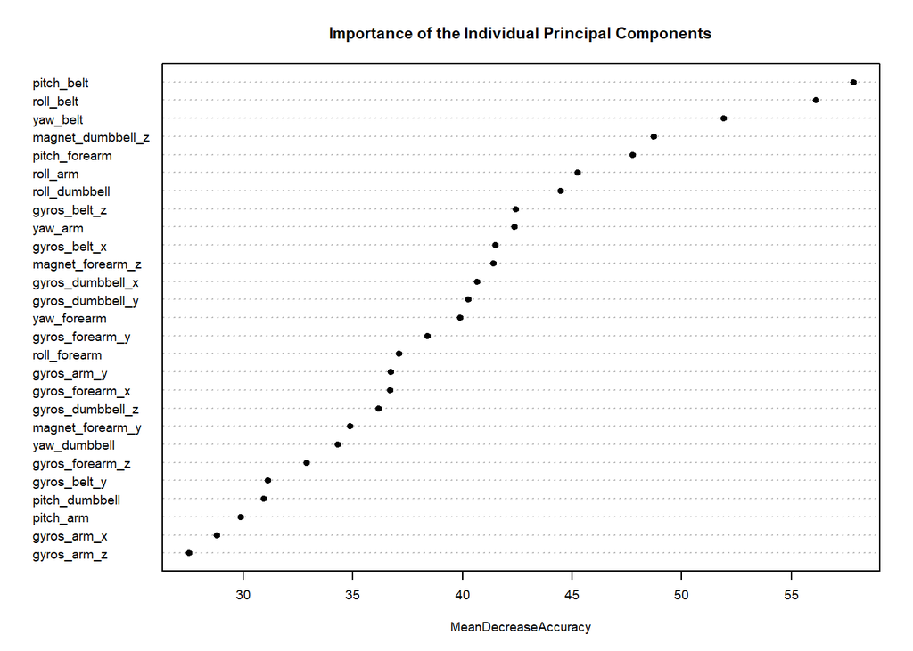

```r
varImpPlot(ranfor$finalModel, sort = TRUE, type = 1, pch = 19, col = 1, cex = 0.6, main = "Importance of the Individual Principal Components")
```

#### Model Evaluation and Validation

To see how much the model performs we will predict the validation data set and see its performance.

```r
validation <- predict(ranfor, valid)
evaluation <- confusionMatrix(valid$classe, validation)
evaluation
```

```
## Confusion Matrix and Statistics
##
##           Reference
## Prediction    A    B    C    D    E
##          A 1669    2    0    0    3
##          B    9 1125    5    0    0
##          C    0   11 1011    4    0
##          D    0    0   11  952    1
##          E    0    0    0    0 1082
##
## Overall Statistics
##
##                Accuracy : 0.9922
##                  95% CI : (0.9896, 0.9943)
##     No Information Rate : 0.2851
##     P-Value [Acc > NIR] : < 2.2e-16
##
##                   Kappa : 0.9901
##
##  Mcnemar's Test P-Value : NA
##
## Statistics by Class:
##
##                      Class: A Class: B Class: C Class: D Class: E
## Sensitivity            0.9946   0.9886   0.9844   0.9958   0.9963
## Specificity            0.9988   0.9971   0.9969   0.9976   1.0000
## Pos Pred Value         0.9970   0.9877   0.9854   0.9876   1.0000
## Neg Pred Value         0.9979   0.9973   0.9967   0.9992   0.9992
## Prevalence             0.2851   0.1934   0.1745   0.1624   0.1845
## Detection Rate         0.2836   0.1912   0.1718   0.1618   0.1839
## Detection Prevalence   0.2845   0.1935   0.1743   0.1638   0.1839
## Balanced Accuracy      0.9967   0.9928   0.9907   0.9967   0.9982
```

The model performed similarly for both training and validation set.

#### Prediction

Now that we have a model we will now predict our testing

```r
pred_test <- predict(ranfor, test)
pred_test
```

```
##  [1] B A B A A E D B A A B C B A E E A B B B
## Levels: A B C D E
```

Here’s the predicted value of our model, these values will now be used for “Course Project Prediction Quiz”.